# Time Series Analysis of Nvidia Stock Prices

## Abstract:

This project focuses on analyzing the time series data of Nvidia’s stock prices. The primary objective is to apply various time series modeling techniques, including SARIMA and other advanced methods, to understand the patterns and forecast future values. The dataset spans several years, providing a comprehensive overview of Nvidia’s market performance. This study aims to uncover significant trends and offer reliable predictions, which are crucial for investors and analysts.

### Name:

Daren Aguilera

daren@ucsb.edu

## 1. Introduction:

This project aims to analyze the stock prices of Nvidia using time series data. Nvidia, a leading technology company known for its graphics processing units (GPUs), has shown significant growth in the stock market. The purpose of this analysis is to apply time series models to understand the underlying patterns and forecast future stock prices. Previous studies have utilized similar methodologies for other tech giants like Apple. By focusing on Nvidia, this project seeks to provide insights into its stock price behavior and identify key trends.

## Xts data frame attempt

```r
# Load the necessary libraries
library(quantmod)
library(xts)
library(naniar)
library(dplyr)
library(forecast)
library(tidyverse)
conflicted::conflict_prefer('lag', 'stats')
```

```
## [conflicted] Will prefer stats::lag over any other package.
```

```r
# Fetch the stock market data

data <- getSymbols("NVDA", src="yahoo", from="2023-01-01", to="2024-05-01", auto.assign=FALSE)

# Check the structure of the data
head(data)
```

```
##            NVDA.Open NVDA.High NVDA.Low NVDA.Close NVDA.Volume NVDA.Adjusted
## 2023-01-03    14.851    14.996   14.096     14.315   401277000      14.30681
## 2023-01-04    14.567    14.853   14.241     14.749   431324000      14.74056
## 2023-01-05    14.491    14.564   14.148     14.265   389168000      14.25683
## 2023-01-06    14.474    15.010   14.034     14.859   405044000      14.85049
## 2023-01-09    15.284    16.056   15.141     15.628   504231000      15.61905
## 2023-01-10    15.507    15.962   15.472     15.909   384101000      15.89989
```

```r
# Convert the data to an xts object and extract the closing prices
nvda_xts <- data[, "NVDA.Close"]

# Display the xts object
nvda <- nvda_xts[,'NVDA.Close']
nvda
```

```
##            NVDA.Close
## 2023-01-03     14.315
## 2023-01-04     14.749
## 2023-01-05     14.265
## 2023-01-06     14.859
## 2023-01-09     15.628
## 2023-01-10     15.909
## 2023-01-11     16.001
## 2023-01-12     16.511
## 2023-01-13     16.899
## 2023-01-17     17.702
##        ...
## 2024-04-17     84.035
## 2024-04-18     84.671
## 2024-04-19     76.200
## 2024-04-22     79.518
## 2024-04-23     82.423
## 2024-04-24     79.677
## 2024-04-25     82.632
## 2024-04-26     87.735
## 2024-04-29     87.757
## 2024-04-30     86.402
```

## Introduction

We will be performing short-term stock predictions for current top technological company listed on the stock market index S&P 500.

**Research Question: How do different do we use historical data of stock market price movements to predict future prices?**

The S&P 500, or Standard & Poor’s 500, is a stock market index that measures the stock performance of 500 of the largest companies listed on the U.S. stock exchange. It is widely regarded as one of the best single gauges of large-cap U.S. equities. The S&P 500 is important because it provides investors with a snapshot of the overall market’s health and the economic performance of the leading companies across various industries. It is also used as a benchmark for investment performance, with many mutual funds and exchange-traded funds (ETFs) attempting to mimic its performance.

The focus of this project is on the Apple listing within the S&P 500, they are involved in many aspects of technological research, development, and distribution of technologically based goods and services. The inclusion of the tech sector is of particular interest due to its rapid growth, innovation, and significant impact on the global economy, although here we will only start with analyzing one company.

For the purpose of this project, we have selected one but the most prominent company within the tech sector of the S&P 500, known not only for their size and market influence but also for their innovative capabilities and role in shaping the future of technology.

A brief overview Apple Inc. (AAPL) is a leader in consumer electronics, software, and services. Apple is best known for its iPhone, iPad, and Mac computers. The company’s integration of hardware, software, and services has established a loyal customer base and made it a key player in the tech industry.

This project aims to explore and compare the predictability of short-term price movements using historical data, providing insights into behaviors within the stock market and the tech sector’s dynamics.

There are 3 primary goals to this analysis. They are:

- Understand Historical Price Movements by Performing an Exploratory Data Analysis (EDA)
- Develop Predictive Models & Evaluate Their Performance
- Compare Predictability Across Models

## Data citation

This data used was gathered from Yahoo Finances accessing and downloading historical data from the top five performing technology companies, as listed [here](https://finance.yahoo.com/u/yahoo-finance/watchlists/tech-stocks-that-move-the-market).

We will begin with loading our dataset. Here we use the downloaded CSV for stock market data acquired from the Yahoo Finance website.

```r
# Loading our dataset from a csv directly off the website
#apple <- read_csv("C:/Users/seren/Downloads/S&P Tech Company Stock Data/data/AAPL.csv")

# Load our codebook we created for feature descriptions
#stock_codebook <- read_csv("C:/Users/seren/Downloads/stock_codebook")
```

We have extracted the raw data from the Yahoo Finance website, although we will practice working with the library `quantmod` to extract our desired data directly from Yahoo while staying within our R environment!

```r
# Using the library 'quantmod' we have access to the function 'getSymbols' where we:
## specify the ticker as represented on the market, specify our data source as Yahoo,
## and the desired range of dates.
data <- getSymbols("AAPL", src="yahoo", from="2023-03-01", to="2024-03-01", auto.assign=FALSE)

# Let's store our data into a data frame for appropriate usage
apple = data.frame(date = index(data), data, row.names=NULL)
```

Now let’s take a slight look into the data we will be working with in this project.

```r
head(apple)
```

```
##         date AAPL.Open AAPL.High AAPL.Low AAPL.Close AAPL.Volume AAPL.Adjusted
## 1 2023-03-01    146.83    147.23   145.01     145.31    55479000      144.3427
## 2 2023-03-02    144.38    146.71   143.90     145.91    52238100      144.9387
## 3 2023-03-03    148.04    151.11   147.33     151.03    70732300      150.0246
## 4 2023-03-06    153.79    156.30   153.46     153.83    87558000      152.8060
## 5 2023-03-07    153.70    154.03   151.13     151.60    56182000      150.5909
## 6 2023-03-08    152.81    153.47   151.83     152.87    47204800      151.8524
```

We notice that there are 7 variables in our dataframe: date, AAPL.Open, AAPL.High, AAPL.Low, AAPL.Close, AAPL.Volume, and AAPL.Adjusted. What these variables directly indicate relative to the stock market is present in our code book. Although the data it comes with is very informative, we can create additional variables later on that will also be able to help us with the goal of outcome prediction. First, let’s make sure to address any potential missing values before we continue to move forward further.

```r
# Check for missing values using the naniar library
apple %>% is_na()
```

```
## [1] FALSE
```

```r
## Note: the base 'is.na' function returns a list of the same sized matrix as the input variable, naniar makes it much cleaner to check for missing values over many cells.
```

With no missing values in any of our datasets, we can proceed with the analysis. This was fairly expected as we extracted the dataset from Yahoo Finances and the S&P index keeps a very consistent record of observations throughout time, which is great for working with a tidy dataset. Although we will take the time to acknowledge `vis_miss()` as a great way to visualize any missing data.

Now let’s practice creating a general function that would be applicable to other companies if we so choose to do so later, although for now we will stick with working around Apple data. `quantmod` has a function called `periodReturn` that when given a set of prices, it will return us discrete financial earnings for the periods that we specify. Since we plan to bind this data as a new column to our primary dataset, we will specify daily returns to match the number of observations avoiding any missing values.

```r
returns <- function(ticker, start_year)
  {
    symbol <- getSymbols(ticker, src = 'yahoo', from="2023-03-01", to="2024-03-01", auto.assign = FALSE, warnings = FALSE)
    data <- periodReturn(symbol, period = 'daily', subset=paste(start_year, "::", sep = ""), type = 'log')
    assign(ticker, data, .GlobalEnv)
  }
re = returns('AAPL', '2023-03-01')

# Bind calculated daily returns as a new column
apple <- bind_cols(apple, re)
```

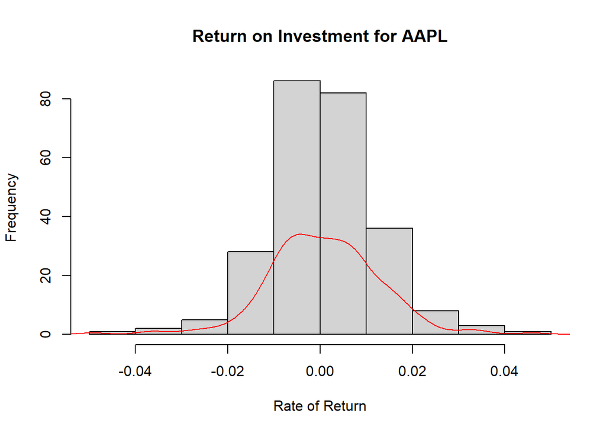

```r
hist(re, main= "Return on Investment for AAPL", xlab="Rate of Return")
lines(density(re), col = "red")
```

Now, similar to the ‘Smarket’ dataset from lab 3, it would be very helpful to work with a factor variable that addresses the direction of the calculated periodic return. We will name this variable Direction as from the original lab.

```r
apple <- apple %>% mutate(
  Direction = ifelse(
    daily.returns > 0, 'Up', 'Down')
  )
# Establish the new variable as a factor
apple$Direction <- apple$Direction %>% factor()
```

Let’s check again for any missing values again now that we’ve added two variables.

```r
apple %>% is_na()
```

```
## [1] FALSE
```

## HW4 Box-Jenkins Apprach

### 1.

Fit a seasonal (S)ARIMA model of your choice to the data you selected in Homework 3 for your final project with the Box-Jenkins approach.

```r
library(quantmod)
library(graphics)
library(astsa)
library(forecast)
```

```r
# data <- getSymbols("NVDA", src="yahoo", from="2023-01-01", to="2024-05-01", auto.assign=FALSE)
#
# # Let's store our data into a data frame for appropriate usage
# nvidia = data.frame(date = index(data), data, row.names=NULL)
# nvidia
#
# nvda <- ts(nvidia$NVDA.Close,
#            start = c(2023,3),
#            frequency = 252)
# nvda
```

#### Step 1. Plot the time series data;

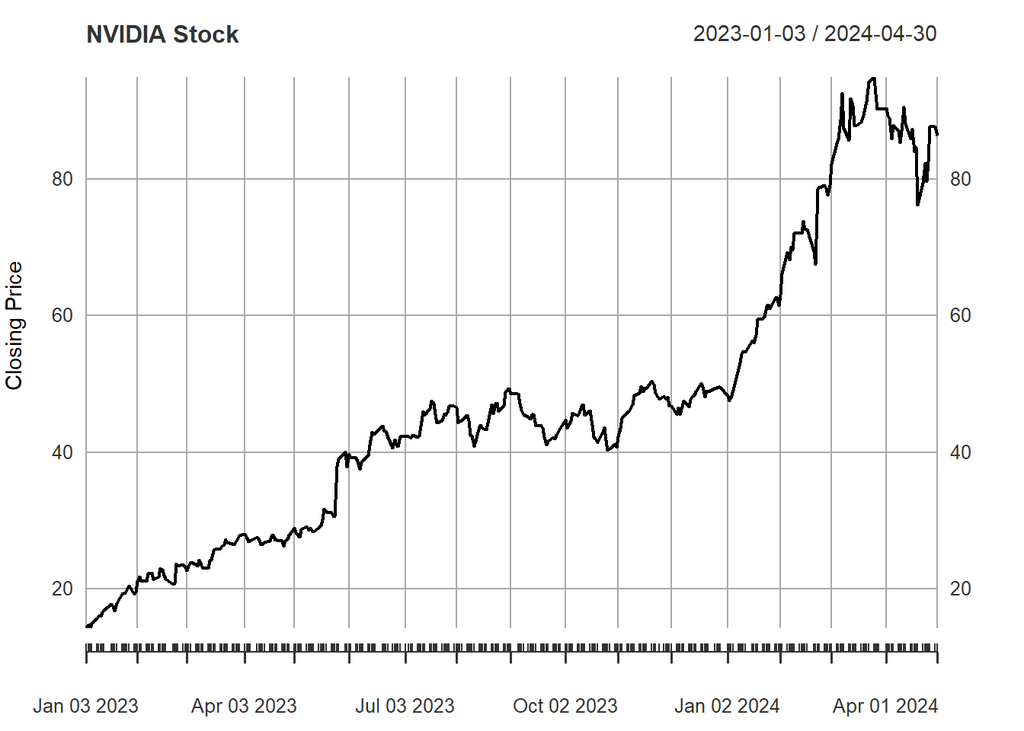

```r
plot(nvda,
     #axes = False,
     ylab = 'Closing Price',
     main = 'NVIDIA Stock')
```

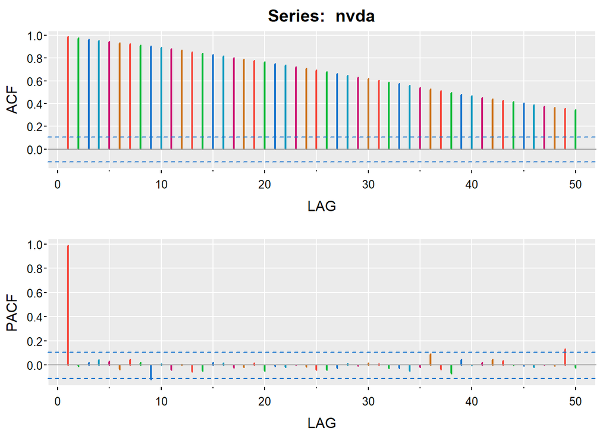

```
##      [,1]  [,2] [,3] [,4] [,5]  [,6] [,7] [,8]  [,9] [,10] [,11] [,12] [,13]
## ACF  0.99  0.98 0.96 0.95 0.94  0.93 0.92 0.91  0.90  0.89  0.88  0.87  0.85
## PACF 0.99 -0.01 0.02 0.04 0.03 -0.04 0.05 0.02 -0.12  0.01 -0.04  0.00 -0.06
##      [,14] [,15] [,16] [,17] [,18] [,19] [,20] [,21] [,22] [,23] [,24] [,25]
## ACF   0.84  0.83  0.82  0.80  0.79  0.78  0.76  0.75  0.74  0.72  0.71  0.69
## PACF -0.05  0.02  0.02 -0.02 -0.02  0.02 -0.05 -0.01 -0.02  0.00 -0.02 -0.04
##      [,26] [,27] [,28] [,29] [,30] [,31] [,32] [,33] [,34] [,35] [,36] [,37]
## ACF   0.68  0.66  0.65  0.63  0.62  0.60  0.59  0.57  0.56  0.54  0.53  0.51
## PACF -0.04 -0.02  0.01 -0.01  0.02  0.01 -0.03 -0.02 -0.05 -0.02  0.09 -0.04
##      [,38] [,39] [,40] [,41] [,42] [,43] [,44] [,45] [,46] [,47] [,48] [,49]
## ACF   0.50  0.48  0.47  0.45  0.44  0.43  0.42  0.40  0.39  0.38  0.36  0.36
## PACF -0.07  0.05  0.00  0.02  0.04  0.04  0.00 -0.01 -0.02  0.00 -0.01  0.13
##      [,50]
## ACF   0.35
## PACF -0.02
```

```r
acf2(nvda, 50, col = 2:7,lwd = 2, gg = TRUE)
```

```r
# plot(x = nvidia$date, y = nvidia$NVDA.Close,
#      #axes = False,
#      xlab = 'Date',
#      ylab = 'Closing Price',
#      main = 'NVIDIA Stock')
#
# acf2(nvidia$NVDA.Close, 50)
```

#### Step 2. Transform (log, Box-Cox power transform)

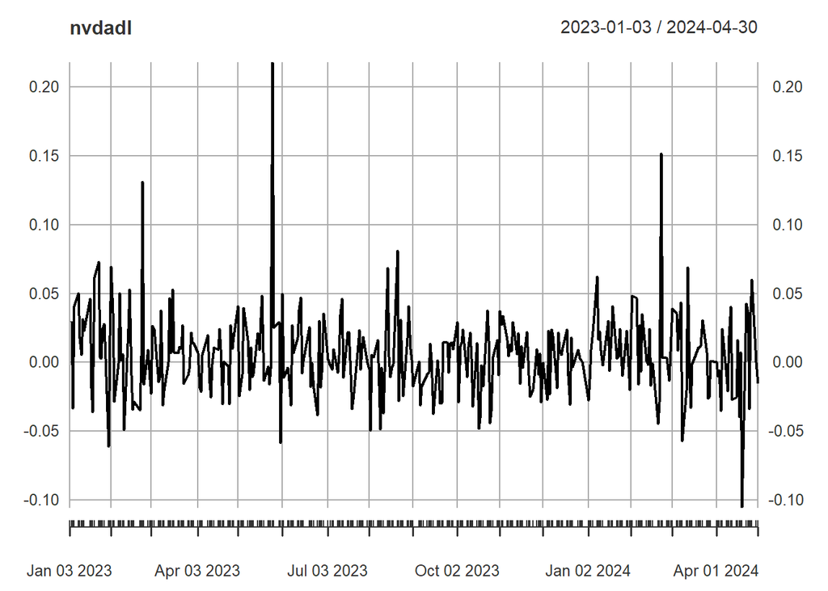

```r
# Take log difference to transform into growth rate or return
#nvdadl <- diff(log(nvidia$NVDA.Close))
nvdadl <- diff(log(nvda))

#plot(x = nvidia$date[-1], y = nvdadl)
plot(nvdadl)
```

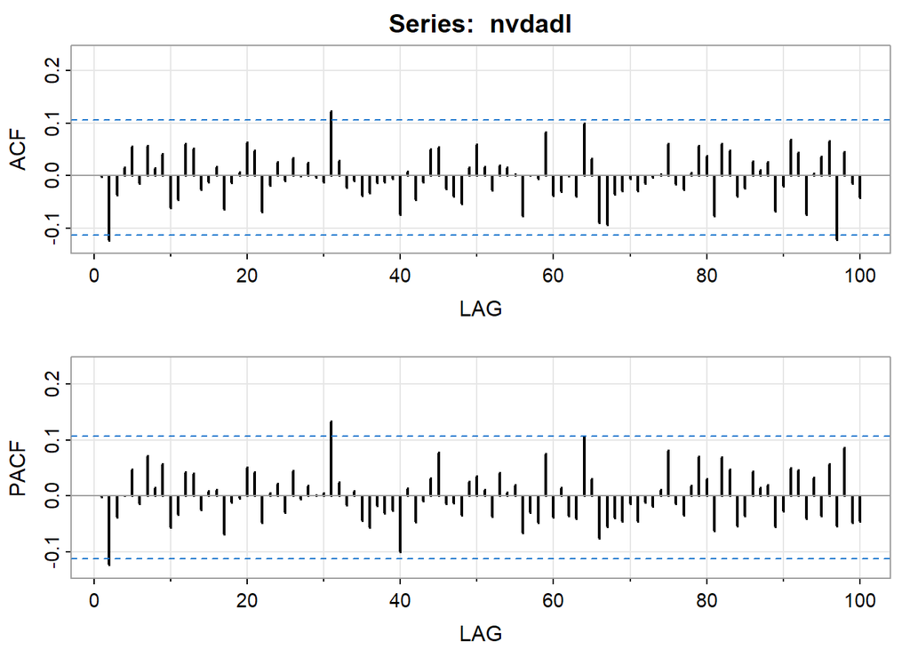

```
##      [,1]  [,2]  [,3] [,4] [,5]  [,6] [,7] [,8] [,9] [,10] [,11] [,12] [,13]
## ACF     0 -0.12 -0.04 0.02 0.06 -0.02 0.06 0.01 0.04 -0.06 -0.05  0.06  0.05
## PACF    0 -0.12 -0.04 0.00 0.05 -0.01 0.07 0.02 0.06 -0.06 -0.03  0.04  0.04
##      [,14] [,15] [,16] [,17] [,18] [,19] [,20] [,21] [,22] [,23] [,24] [,25]
## ACF  -0.03 -0.01  0.02 -0.06 -0.01  0.01  0.06  0.05 -0.07 -0.02  0.03 -0.01
## PACF -0.03  0.01  0.01 -0.07 -0.01 -0.01  0.05  0.04 -0.05  0.00  0.02 -0.03
##      [,26] [,27] [,28] [,29] [,30] [,31] [,32] [,33] [,34] [,35] [,36] [,37]
## ACF   0.03  0.00  0.02     0 -0.01  0.12  0.03 -0.02 -0.01 -0.04 -0.03 -0.01
## PACF  0.04 -0.01  0.02     0  0.00  0.13  0.02 -0.02  0.01 -0.04 -0.06 -0.02
##      [,38] [,39] [,40] [,41] [,42] [,43] [,44] [,45] [,46] [,47] [,48] [,49]
## ACF  -0.01 -0.01 -0.07  0.01 -0.05 -0.01  0.05  0.05 -0.03 -0.04 -0.05  0.02
## PACF -0.03 -0.03 -0.10  0.01 -0.05 -0.01  0.03  0.08 -0.01 -0.01 -0.03  0.03
##      [,50] [,51] [,52] [,53] [,54] [,55] [,56] [,57] [,58] [,59] [,60] [,61]
## ACF   0.06  0.02 -0.03  0.02  0.02  0.00 -0.08  0.00 -0.01  0.08 -0.04 -0.03
## PACF  0.04  0.01 -0.04  0.04  0.01  0.02 -0.07 -0.03 -0.05  0.08 -0.04  0.01
##      [,62] [,63] [,64] [,65] [,66] [,67] [,68] [,69] [,70] [,71] [,72] [,73]
## ACF   0.00 -0.04  0.10  0.03 -0.09 -0.09 -0.04 -0.03 -0.01 -0.03 -0.01  0.00
## PACF -0.04 -0.04  0.11  0.03 -0.08 -0.06 -0.04 -0.05 -0.01 -0.05 -0.01 -0.02
##      [,74] [,75] [,76] [,77] [,78] [,79] [,80] [,81] [,82] [,83] [,84] [,85]
## ACF   0.00  0.06 -0.02 -0.03  0.01  0.06  0.04 -0.08  0.06  0.05 -0.04 -0.02
## PACF  0.01  0.08 -0.01 -0.04  0.02  0.07  0.03 -0.06  0.07  0.05 -0.05 -0.04
##      [,86] [,87] [,88] [,89] [,90] [,91] [,92] [,93] [,94] [,95] [,96] [,97]
## ACF   0.03  0.01  0.03 -0.07 -0.02  0.07  0.04 -0.07  0.00  0.04  0.07 -0.12
## PACF  0.04  0.02  0.02 -0.06 -0.03  0.05  0.05 -0.04  0.03 -0.04  0.06 -0.05
##      [,98] [,99] [,100]
## ACF   0.05 -0.02  -0.04
## PACF  0.09 -0.05  -0.05
```

```r
acf2(nvdadl, 100, lwd = 2)
```

#### Step 3. Identification of the difference d .

Taking the return of the original dataset, we identify the difference as 1 since no more is needed, else we risk creating dependence when there should not be.

Additionally looking at the transformation, we can identify two different models from where the ACF and PACF cut off.

PACF cuts off at 2, so our first model will be based off AR(2)

ACF appears to cut off at 2 as well so our other model will be MA(2)

#### Step 4. Estimation of parameters

```r
# AR2
sarima(nvdadl, 2, 0, 0)
```

```
## <><><><><><><><><><><><><><>
##
## Coefficients:
##       Estimate     SE t.value p.value
## ar1    -0.0026 0.0545 -0.0482  0.9616
## ar2    -0.1234 0.0545 -2.2621  0.0243
## xmean   0.0054 0.0015  3.7025  0.0003
##
## sigma^2 estimated as 0.0009017096 on 329 degrees of freedom
##
## AIC = -4.149152  AICc = -4.148932  BIC = -4.103307
##
```

[figure not shown]

```r
# MA2
sarima(nvdadl, 0, 0, 2)
```

```
## <><><><><><><><><><><><><><>
##
## Coefficients:
##       Estimate     SE t.value p.value
## ma1    -0.0090 0.0544 -0.1647  0.8693
## ma2    -0.1217 0.0537 -2.2648  0.0242
## xmean   0.0054 0.0014  3.7763  0.0002
##
## sigma^2 estimated as 0.0009018547 on 329 degrees of freedom
##
## AIC = -4.148993  AICc = -4.148773  BIC = -4.103148
##
```

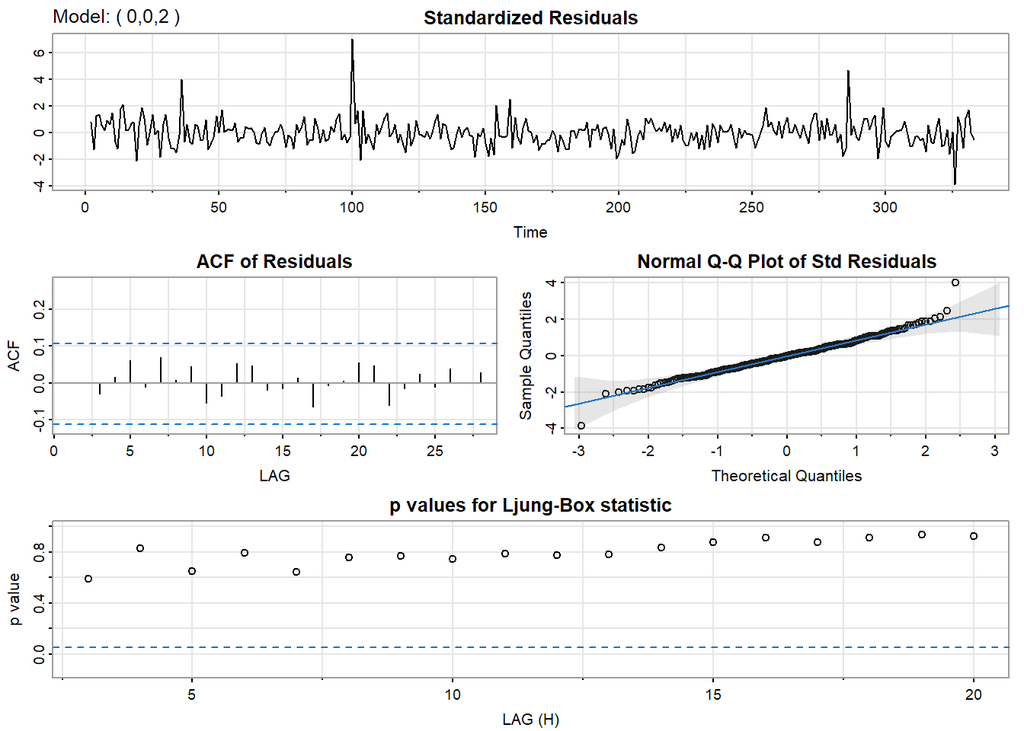

#### Step 5. Diagnostics

Now looking at the diagnostic plots, we can see a similar result for both models.

- The standardized residuals plot does have an average of 0, although we see about four outliers that are at least three standard deviations greater than the average.
- Looking at the ACF of residuals, we notice that both of them are within normal bounds for all lag values displayed up to 30.
- Next, the Q-Q plots of standardized residuals show us the, approximately four, outliers mentioned earlier.
- Lastly, the p-values for Ljung-Box statistic (Q), have high values with the first lag being the smallest just below 0.6 for both models. Then thoroughly maintaining high values for lags displayed up to 20.

##### Step 6. Model Selection

For our first model we obtained criterions: AIC = -4.149152 AICc = -4.148932 BIC = -4.103307

For the second model, we obtain: AIC = -4.148993 AICc = -4.148773 BIC = -4.103148

### 2.

Use the estimated model and forecast the next 12 data points in the future of your dataset (for example, monthly data, 12 months = 1 year prediction).

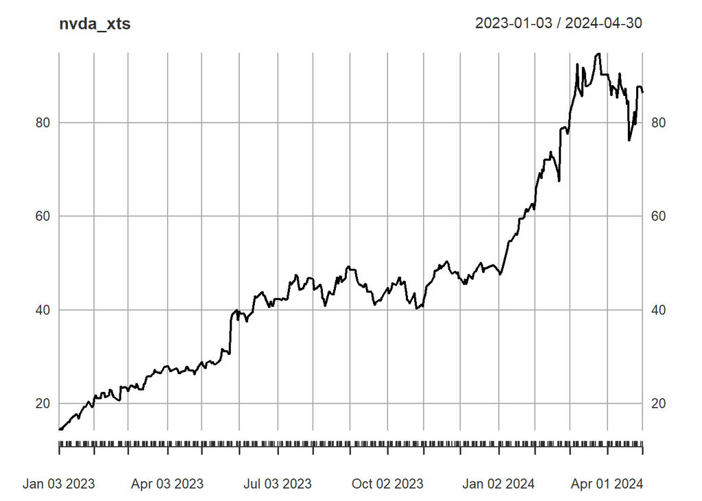

```r
nvda_ols <- ar.ols(nvda_xts, order = 2, demean = FALSE, intercept = TRUE)
fore <- predict(nvda_ols, n.ahead = 12)

#ts.plot(rec, fore$pred, col=1:2, xlim=c(1980,1990), ylab="Recruitment")
#ts.plot(nvidia$NVDA.Close, fore$pred, col=1:2)#, col = 1:2)#, xlim = c(333,344), ylim = c(0,1))
plot(nvda_xts, fore$pred, col=1:2)#, xlim = c(2024.1,2024.37), ylim = c(450,950))
#plot(fore, fore$pred)
U = fore$pred+fore$se; L = fore$pred-fore$se
xx = c(time(U), rev(time(U))); yy = c(L, rev(U))
polygon(xx, yy, border = 8, col = gray(.6, alpha = .2))
lines(fore$pred, type="p", col=2)
```